# working_with_coszen_errors slides

## What is the problem?

First, does a uniformly-random reconstruction end up looking "good" if we marginalize over $\cos\theta_{\rm true}$?

In order to answer this, first draw $\cos\theta_{\rm true}$ at random from $[-1,1]$. Then for each point, construct $\cos\theta_{\rm reco}$ as another (independently random) number drawn from $[-1,1]$.

```python
rnd1 = np.random.RandomState(seed=1234)
rnd2 = np.random.RandomState(seed=5678)
N = int(1e4)
cz_true = rnd1.uniform(low=-1, high=1, size=N)
cz_reco = rnd2.uniform(low=-1, high=1, size=N)
cz_err = cz_reco - cz_true
```

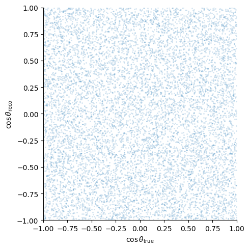

```python
f, ax1 = plt.subplots(1, 1, figsize=(5, 5))
ax1.plot(cz_true, cz_reco, 'o', ms=2, mew=0, alpha=0.2)
ax1.set_ylabel(r'$%s$' % reco_coszen.tex)
ax1.set_ylim(-1, 1);ax1.set_xlim(-1, 1)
removeBorder(ax1)
ax1.set_xlabel('$%s$' % true_coszen.tex)
f.tight_layout()
```

Plotting this as reco-coszen *error* and histogramming over the error yields the following unnatural-looking plots:

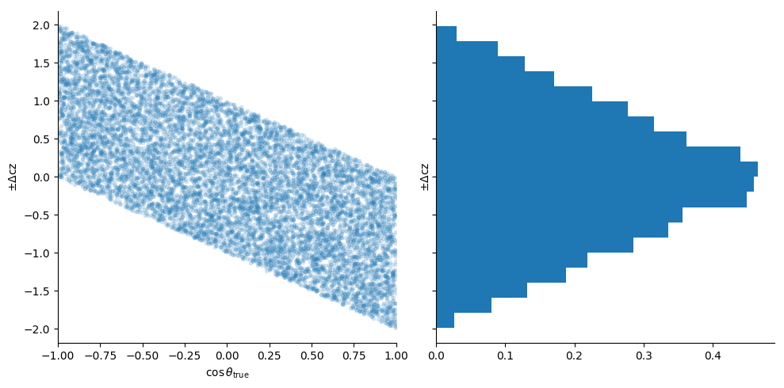

```python
plot_cz_err_dist(cz_true, cz_err, label=r'$\pm \Delta {\rm cz}$');
```

While the reco is perfectly random, the distribution of reco-coszen error on the right will lead to the false conclusion that we get "truth" more often than not. So this is a very bad bug in the `vbwkde` stage as it's written now!

## How to fix the problem?

### Strategy 1: Randomly assign a sign

```python
rnd3 = np.random.RandomState(seed=1)
cz_err_rand_sign = cz_err * rnd3.choice((-1, +1), size=N)
```

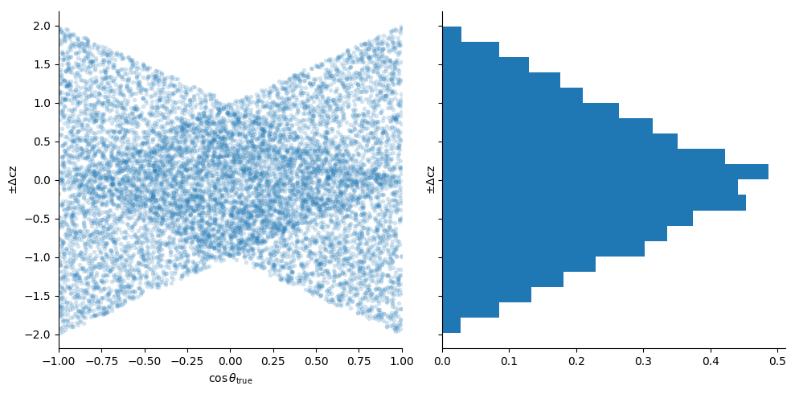

```python
plot_cz_err_dist(cz_true, cz_err_rand_sign, label=r'$\pm \Delta {\rm cz}$');
```

### Strategy 2: Take the above and fold in values beyond $\pm$ 1

```python
def fold_cz_err(cz_err, randomize=False):
    if randomize:
        rnd = np.random.RandomState(seed=1)
        cz_err = cz_err * rnd.choice((-1, +1), size=cz_err.shape)
    mask = cz_err > 1
    cz_err[mask] = 2 - cz_err[mask]
    mask = cz_err < -1
    cz_err[mask] = -2 - cz_err[mask]
    return cz_err
```

```python
cz_err_rand_sign_folded = fold_cz_err(deepcopy(cz_err_rand_sign))
```

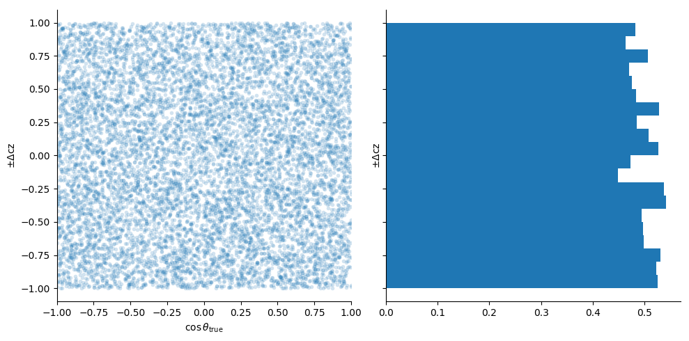

```python
plot_cz_err_dist(cz_true, cz_err_rand_sign_folded,
                 label=r'$\pm \Delta {\rm cz}$');
```

So this appears to work. The distribution is restored to be uniform in both true and reco axes.

### Strategy 3: Can we skip the first step, and just do the folding?

I'm a little uncomfortable adding the randomness, since that presents yet another variable in our analysis. Can we get away with just folding the corners inwards?

```python
cz_err_folded = fold_cz_err(deepcopy(cz_err))
```

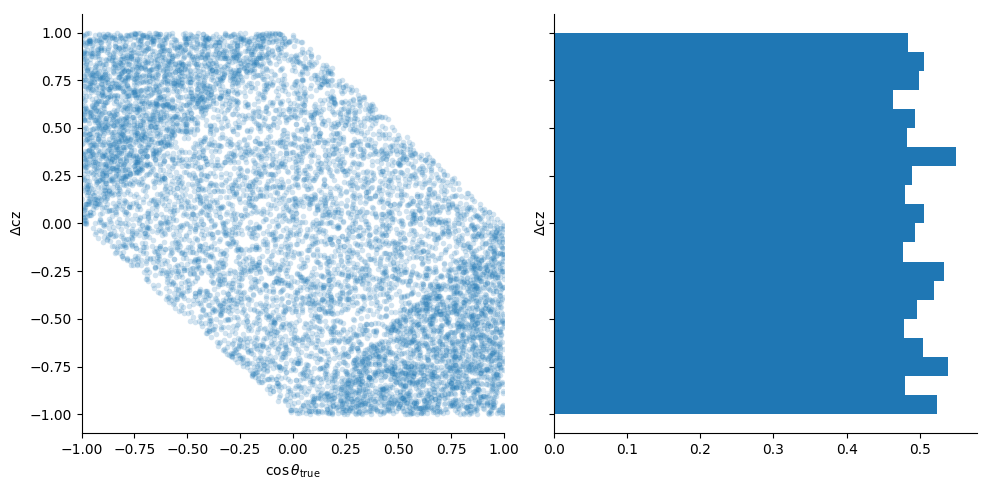

```python
plot_cz_err_dist(
    cz_true, cz_err_folded,
);
```

As seen above, so long as we're marginalizing out the true coszen, the error distribution in reco-coszen error looks fine here, so this **does work**.

However, if we're not marginalizing out true coszen, we would still want to go with randomizing the sign first, and then folding. As you can see above, the full 2D distribution of points is *not* uniform, and difficult to see by eye that it *is* uniform when true coszen is marginalized over.

### How does VBW-KDE work when applied to this?

Due to my lack of patience, I'll downsample by a factor `dec` defined below to make the following faster.

```python
dec = int(np.floor(N / 500))
print 'Number of datapoints after %dx decimation: %d' % (dec, N//dec)
```

```
Number of datapoints after 20x decimation: 500
```

Now apply VBW KDE...

```python
bw, samp_cz_err, samp_cz_err_dist = vbw_kde(cz_err_folded[::dec])
```

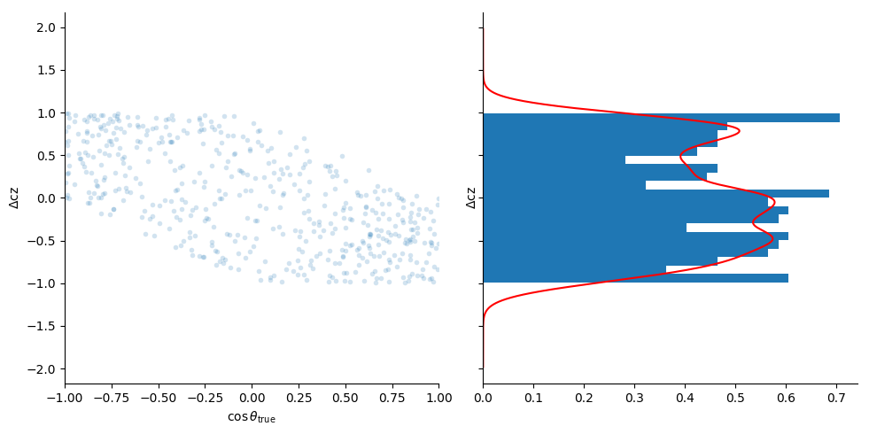

```python
f, ax1, ax2 = plot_cz_err_dist(cz_true[::dec], cz_err_folded[::dec])
ax2.plot(samp_cz_err_dist, samp_cz_err, 'r-');
```

Unfortunately, this doesn't look very good.

#### Try duplicating the data, mirrored about $\pm$1, to remove edge effects

```python
cz_err_folded_mirrored = np.concatenate([
    cz_err_folded[::dec],
    +2 - cz_err_folded[::dec],
    -2 - cz_err_folded[::dec]
])
cz_true_mirrored = np.concatenate([cz_true[::dec]]*3)
```

```python
bw_mir, samp_cz_err_mir, samp_cz_err_dist_mir = vbw_kde(
    cz_err_folded_mirrored, n_dct=2**12, n_addl_iter=0
)
```

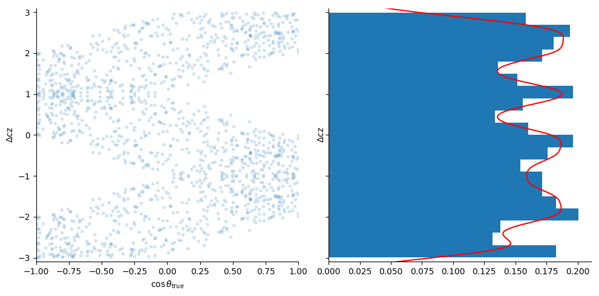

```python
f, ax1, ax2 = plot_cz_err_dist(cz_true_mirrored, cz_err_folded_mirrored)
ax2.plot(samp_cz_err_dist_mir, samp_cz_err_mir, 'r-')
ax2.set_ylim(-3.1, 3.1);
```

Note that VBW KDE isn't doing very well in capturing the "flatness" of this distribution. I believe this is related to the "bug" I identified previously: It uses the density of the pilot distribution *relative* to the identified peak (which is found via the ISJ FBW KDE pilot) as the normalization factor $h$ for the Abramson bandwidth selction $${\rm BW} = h\cdot {\rm dens}^{-1/2}.$$

We *should* be using some *absolute* density instead, so that we have better behavior in these now-identified cases:

1. Uniform distribution, where a peak is anomalous; *all* bandwidths should be roughly the same, but determined by the pilot estimate of density there
2. High number of samples, where we can use bandwidths *smaller* than the ISJ bandwidth (which tends to capture the peak's bandwidth well... but then we lose detail there and everywhere else, when we have lots of samples!)

We'll just take the middle-most portion of the KDE, and so we'll also need to renormalize "manually" (i.e., via `np.trapz`).

```python
ix = reco_coszen.bin_edges.m
iy = np.interp(
    x=ix,
    xp=samp_cz_err_mir,
    fp=samp_cz_err_dist_mir
)
area = np.trapz(y=iy, x=ix)
iy /= area
```

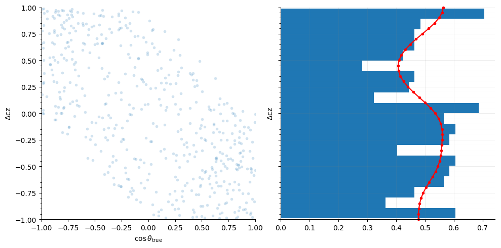

```python
f, ax1, ax2 = plot_cz_err_dist(cz_true[::dec], cz_err_folded[::dec])
ax2.plot(iy, ix, 'r.-', clip_on=False)
ax2.set_ylim(min(reco_coszen.bin_edges.m), max(reco_coszen.bin_edges.m));
ax2.set_yticks(ix, minor=True)
ax2.grid(b=True, which='major', **MAJOR_GRID_FMT)
ax2.grid(b=True, which='minor', **MINOR_GRID_FMT)
```

This doesn't look as bad as it could, but it doesn't look terribly good, either. I wish that the VBW KDE did better accounting of "uncertainty" here by making the kernels wider.

#### *Or:* let wraparound property of FFT reduce edge effects

If we simply define the KDE computational range as being strictly the data's range, then presumably the FFT's natural wraparound effect can help us (and this is valid, considering an error of -1 is the same as having an error of +1, i.e., $\pm$180$^\circ$).

```python
bw_tight, samp_cz_err_tight, samp_cz_err_dist_tight = vbw_kde(
    cz_err_folded[::dec], min=-1, max=+1, n_addl_iter=20, n_dct=2**12,
)
```

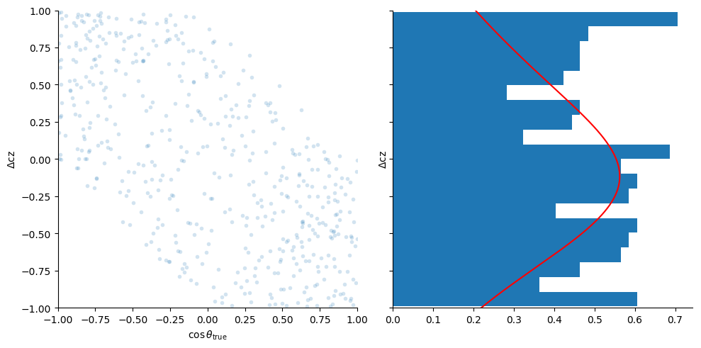

```python
f, ax1, ax2 = plot_cz_err_dist(cz_true[::dec], cz_err_folded[::dec])
ax2.plot(samp_cz_err_dist_tight, samp_cz_err_tight, 'r-')
ax2.set_ylim(-1, 1);
```

Well, that failed miserably. Not sure what the problem is here, not going to try to debug it now.